# Robust Mixture Prior

Here is the breakdown of how to mathematically connect the prior weight to the Effective Sample Size (ESS), followed by an implementation in R.

Part 1: Selecting Weight Based on Effective Sample Size (ESS)

In Bayesian design, we rarely pick the weight $w$ arbitrarily. Instead, we select $w$ to limit the amount of information we “borrow” from history. This is quantified as the Prior Effective Sample Size (ESS).The relationship between the weight $w$ and ESS in a mixture model is non-linear and depends on the “distance” between the informative and robust components.

1. The Concept (Morita’s Definition)

The most standard mathematical definition (Morita et al., 2008) equates the information in the prior to the information contained in a hypothetical number of observations.If our sampling distribution (likelihood) has a single observation information $I_1(\theta)$, and our prior $\pi(\theta)$ has information $I_\pi(\theta)$, then:
$$ESS_{\pi} = \frac{I_\pi(\theta)}{I_1(\theta)}$$
2. The Calculation

For a robust mixture prior $\pi(\theta) = w\pi_{inf}(\theta) + (1-w)\pi_{rob}(\theta)$, the information $I_\pi(\theta)$ is defined by the curvature of the log-prior density (the second derivative).
$$I_\pi(\theta) = - E \left[ \frac{\partial^2 \log \pi(\theta)}{\partial \theta^2} \right]$$
Because the mixture density involves a logarithm of a sum ($\log(w \cdot A + (1-w) \cdot B)$), this usually creates a closed-form expression that is difficult to solve algebraically.

3. The Practical Strategy

Practitioners generally use a numerical approach to select $w$:

Define $\pi_{inf}$: Set the informative component based on historical data (e.g., $N_{hist} = 100$).

Define $\pi_{rob}$: Set the robust component (e.g., Unit Information Prior, equivalent to $N=1$).

Set Target ESS: Decide the maximum “strength” you want to borrow (e.g., “I want this prior to be worth no more than 20 patients”).

Solve for $w$: We numerically iterate $w$ (from 0 to 1) until the calculated ESS of the mixture matches the Target ESS.

Key Insight: A 50% weight ($w=0.5$) does not generally mean you have 50% of the historical sample size. Due to the heavy tails of the robust component, you often need a higher weight to achieve a moderate ESS.

Part 2: R Code Implementation

We will use the RBesT package (R Bayesian Evidence Synthesis Tools). It is the pharmaceutical industry standard for RMPs because it automatically handles the complex ESS calculations described above.

Scenario:History: A previous trial had 50 patients, observing a treatment effect of mean 1.5 (Standard Error 0.2).

Goal: Create a Robust Mixture Prior that borrows from this history but limits the max ESS to 20 patients (we want to be conservative).

```r
library(RBesT)
library(ggplot2)

# --- STEP 1: Define Historical Data & Reference Scale ---
# Historical study: N=50, Mean=1.5, SE=0.2
map_prior <- mixnorm(c(1, 1.5, 0.2), param="ms")

# Calculate the single-patient standard deviation (Reference Sigma)
# We need this for the ESS calculation.
ref_sigma <- 0.2 * sqrt(50)

# --- STEP 2: Solver Function ---
target_ESS <- 20

find_ESS_diff <- function(w_rob) {
  # robustify() adds a robust component with weight 'w_rob'
  # sigma=2 represents the wide/vague component width
  tmp_prior <- robustify(map_prior, weight = w_rob, mean = 0, sigma = 2)

  # CRITICAL FIX: We must pass 'sigma = ref_sigma' to ess()
  # so it knows what "one patient" looks like.
  current_ESS <- ess(tmp_prior, method = "elir", sigma = ref_sigma)

  return(current_ESS - target_ESS)
}

# --- STEP 3: Solve for the Weight ---
# Find the weight (between 1% and 99%) that gives us ESS = 20
opt_result <- uniroot(find_ESS_diff, interval = c(0.01, 0.99))
optimal_robust_weight <- opt_result$root

# --- STEP 4: Create Final Prior ---
robust_prior_final <- robustify(map_prior, weight = optimal_robust_weight, mean = 0, sigma = 2)

# --- STEP 5: Inspect and Plot ---
final_ESS <- ess(robust_prior_final, method = "elir", sigma = ref_sigma)

print(paste("Reference Sigma (1 patient):", round(ref_sigma, 3)))
```

```
[1] "Reference Sigma (1 patient): 1.414"
```

```r
print(paste("Required Weight on Robust Component:", round(optimal_robust_weight, 3)))
```

```
[1] "Required Weight on Robust Component: 0.467"
```

```r
print(paste("Final Effective Sample Size:", round(final_ESS, 1)))
```

```
[1] "Final Effective Sample Size: 20"
```

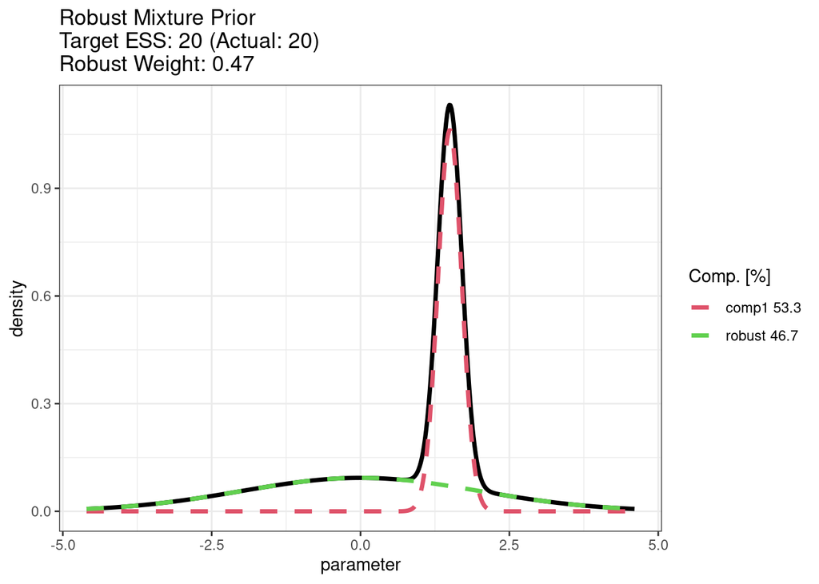

```r
# Plot the distribution
plot(robust_prior_final) +
  ggtitle(paste0("Robust Mixture Prior\n",
                 "Target ESS: 20 (Actual: ", round(final_ESS, 1), ")\n",
                 "Robust Weight: ", round(optimal_robust_weight, 2))) +
  theme_bw()
```

To calculate the Operating Characteristics (OC), we perform a **simulation study**. We repeatedly simulate the new trial under different “Truth” scenarios (e.g., the drug works, the drug doesn’t work) and calculate two things:

1. **Type I Error (False Positive Rate):** If the drug truly has **zero effect**, how often does our Robust Mixture Prior trick us into declaring success because of the historical bias?
2. **Power:** If the drug **truly works**, how often do we correctly declare success?

```r
library(RBesT)
library(ggplot2)
library(dplyr)
# --- 1. SETUP PRIORS ---
# A. Historical Data (Reference Scale)
ref_sigma <- 1 * sqrt(50) # Approx 1.414

# B. Simple Informative Prior (Pure History)
# This assumes the history is 100% relevant. No robust component.
simple_inf_prior <- mixnorm(c(1, 1.5, 1), param="ms")
simple_inf_prior1 <- mixnorm(c(1, 2, 1), param="ms")

# C. Robust Mixture Prior (Target ESS = 20)
# Uses the informative component mixed with a vague component
robust_prior <- robustify(simple_inf_prior, weight = 0.44, mean = 0, sigma = 2)

# D. Standard Flat Prior (No History)
flat_prior <- mixnorm(c(1, 0, 100), param="ms")

# --- 2. DEFINE SIMULATION FUNCTION ---
simulate_power <- function(prior, n_patients, true_mean, sigma, decision_thresh, iterations=2000) {
  trial_se <- sigma / sqrt(n_patients)
  success_count <- 0

  for(i in 1:iterations) {
    obs_mean <- rnorm(1, mean = true_mean, sd = trial_se)
    posterior <- postmix(prior, m = obs_mean, se = trial_se)

    # Decision: Probability Mean > 0
    prob_positive <- pmix(posterior, 0, lower.tail = FALSE)

    if(prob_positive > decision_thresh) {
      success_count <- success_count + 1
    }
  }
  return(success_count / iterations)
}

# --- 3. RUN SIMULATION ---
true_effects <- seq(0, 2, by = 0.2)
n_new <- 50
threshold <- 0.975

results <- data.frame()
print("Starting 3-Way Simulation...")
```

```
[1] "Starting 3-Way Simulation..."
```

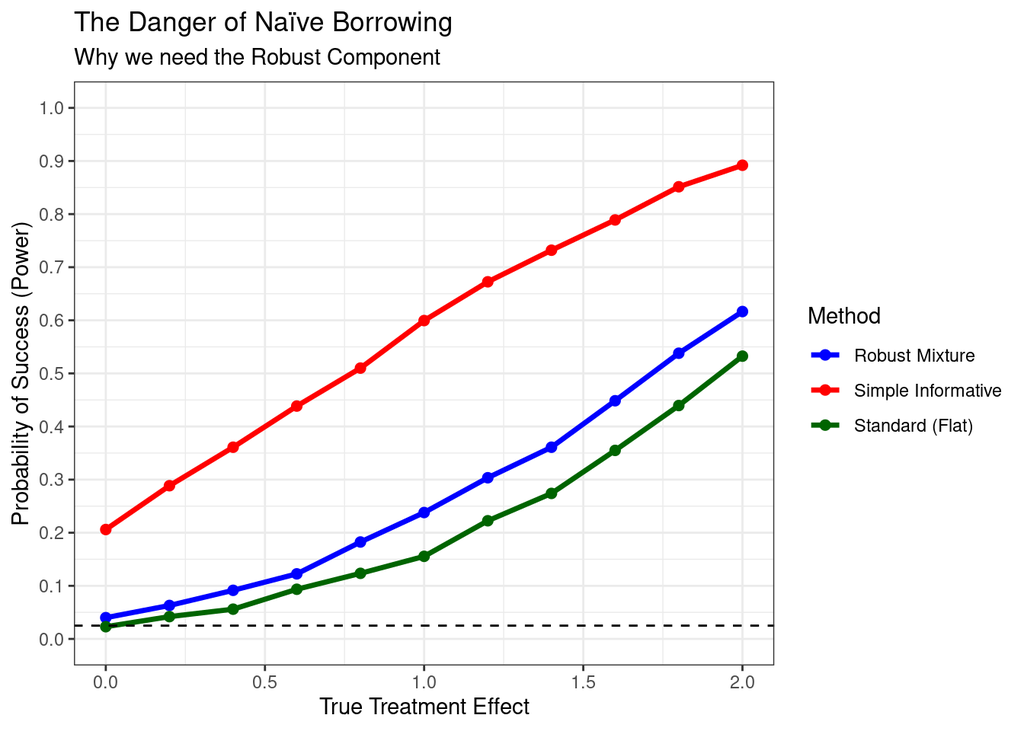

```r
for(mu in true_effects) {
  # 1. Robust
  p_rob <- simulate_power(robust_prior, n_new, mu, ref_sigma, threshold)
  results <- rbind(results, data.frame(TrueMean=mu, Power=p_rob, Method="Robust Mixture"))

  # 2. Standard
  p_flat <- simulate_power(flat_prior, n_new, mu, ref_sigma, threshold)
  results <- rbind(results, data.frame(TrueMean=mu, Power=p_flat, Method="Standard (Flat)"))

  # 3. Simple Informative
  p_inf <- simulate_power(simple_inf_prior1, n_new, mu, ref_sigma, threshold)
  results <- rbind(results, data.frame(TrueMean=mu, Power=p_inf, Method="Simple Informative"))
}

# --- 4. VISUALIZE ---
# We define custom colors to make the distinction clear
# Red = Danger (Simple Informative), Green = Safe (Standard), Blue = Balanced (Robust)



ggplot(results, aes(x = TrueMean, y = Power, color = Method)) +
  geom_line(linewidth = 1.2) +
  geom_point(size = 2) +
  geom_hline(yintercept = 0.025, linetype = "dashed") +
  scale_y_continuous(breaks = seq(0, 1, 0.1), limits = c(0, 1)) +
  scale_color_manual(values = c("Robust Mixture" = "blue",
                                "Standard (Flat)" = "darkgreen",
                                "Simple Informative" = "red")) +
  labs(title = "The Danger of Naïve Borrowing",
       subtitle = "Why we need the Robust Component",
       x = "True Treatment Effect",
       y = "Probability of Success (Power)") +
  theme_bw()
```

```r
# Print the Type I Errors
t1_inf <- results[results$TrueMean == 0 & results$Method == "Simple Informative", "Power"]
print(paste("Type I Error (Simple Informative):", t1_inf))
```

```
[1] "Type I Error (Simple Informative): 0.206"
```

- **Posterior Weights** tell you **“Who is driving the car?”** (The Informative Prior or the Robust Prior?)
- **Posterior Probability** tells you **“Where is the car going?”** (Is the drug effective?)
- The **Robustness** comes from the fact that if the data is bad, the **Posterior Weight** shifts to the Robust component, which then steers the **Posterior Probability** towards a safer, unbiased conclusion.

```r
library(RBesT)

# 1. Setup Prior
map_prior <- mixnorm(c(1, 1.5, 0.2), param="ms")
robust_prior <- robustify(map_prior, weight = 0.5, mean = 0, sigma = 2)

# 2. Update with CONFLICTING Data (Data says 0, History says 1.5)
post_conflict <- postmix(robust_prior, m = 0, se = 0.2)

# --- HOW TO SEE THE WEIGHTS ---

# Method A: Just print the object directly
print("--- Detailed Component View (Look for 'w' column) ---")
```

```
[1] "--- Detailed Component View (Look for 'w' column) ---"
```

```r
print(post_conflict)
```

```
Univariate normal mixture
Mixture Components:
  comp1        robust
w 5.551075e-06 9.999944e-01
m 7.500000e-01 0.000000e+00
s 1.414214e-01 1.990074e-01
```

```r
# Method B: Extract just the weights specifically
print("--- Extracted Weights ---")
```

```
[1] "--- Extracted Weights ---"
```

```r
# Row 1 is usually the Informative Component
# Row 2 is usually the Robust Component
weights <- post_conflict["w",]
names(weights) <- c("Informative (Comp 1)", "Robust (Comp 2)")
print(round(weights, 4))
```

```
Informative (Comp 1)      Robust (Comp 2)
                   0                    1
```

Math: How is the weight actually calculated?

Since you asked about the relationship, here is the formula for how R calculates that new w. It uses the Marginal Likelihood (how well did each expert predict the data?).
$$\tilde{w}_1 = \frac{w_1 \times L_1(Data)}{w_1 \times L_1(Data) + w_2 \times L_2(Data)}$$
Where:$w_1, w_2$: The starting weights (e.g., 0.5, 0.5). $L_1(Data)$: The likelihood (probability) of seeing the new data if the Informative Expert was right. $L_2(Data)$: The likelihood of seeing the new data if the Robust Expert was right.Because the data fell far away from the Informative distribution, $L_1$ was a tiny number, causing the updated weight $\tilde{w}_1$ to crash to zero.

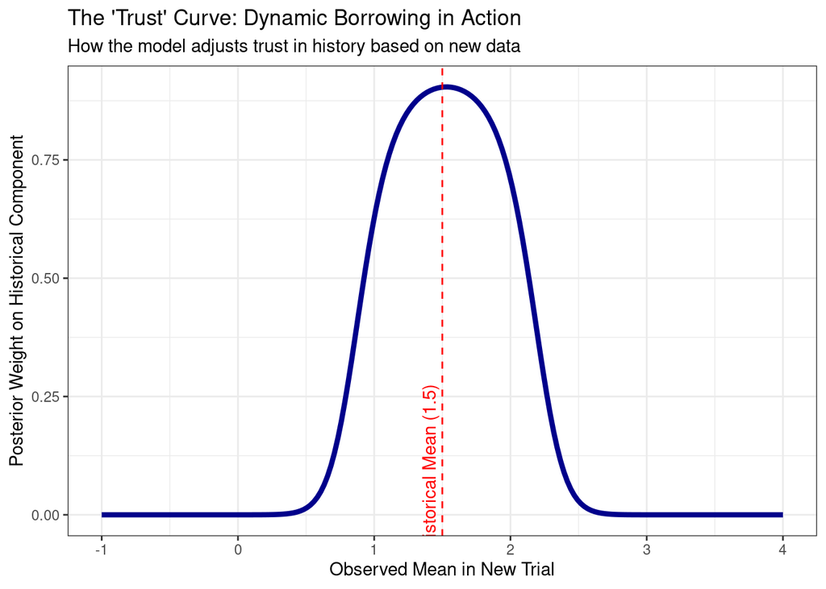

```r
library(RBesT)
library(ggplot2)

# --- 1. SETUP ---
# Historical Data (The "Informative" Component)
# Mean = 1.5, SE = 0.2
map_prior <- mixnorm(c(1, 1.5, 0.2), param="ms")

# Robust Mixture Prior
# We give 50% initial trust to history, 50% to robust component
# Note: In real life, the initial weight might be smaller, but 0.5 makes the visual clear.
robust_prior <- robustify(map_prior, weight = 0.5, mean = 0, sigma = 2)

# --- 2. SIMULATION LOOP ---
# We test a range of possible outcomes for the new trial
# From -1 (Conflict) to 1.5 (Match) to 4 (Conflict)
outcome_grid <- seq(-1, 4, length.out = 200)

# We assume the new trial has the same precision as the old one (SE = 0.2)
trial_se <- 0.2

# Function to calculate the posterior weight for a specific outcome
get_posterior_weight <- function(observed_mean) {
  # Update the prior with this specific outcome
  post <- postmix(robust_prior, m = observed_mean, se = trial_se)

  # Extract the weight of Component 1 (The Informative Component)
  # post[1, "w"] grabs the first row's weight
  return(post["w", 1])
}

# Apply function to all outcomes
weights <- sapply(outcome_grid, get_posterior_weight)

# --- 3. VISUALIZATION ---
plot_data <- data.frame(Outcome = outcome_grid, Weight = weights)



ggplot(plot_data, aes(x = Outcome, y = Weight)) +
  geom_line(color = "darkblue", linewidth = 1.5) +

  # Add reference line for the Historical Mean
  geom_vline(xintercept = 1.5, linetype = "dashed", color = "red") +
  annotate("text", x = 1.5, y = 0.1, label = "Historical Mean (1.5)", color = "red", angle = 90, vjust = -0.5) +

  labs(title = "The 'Trust' Curve: Dynamic Borrowing in Action",
       subtitle = "How the model adjusts trust in history based on new data",
       x = "Observed Mean in New Trial",
       y = "Posterior Weight on Historical Component") +
  theme_bw()
```

The mathematical beauty of a Mixture Prior is that it follows a “Divide and Conquer” strategy.Instead of trying to update the complex “double-humped” shape all at once, the math splits the problem into two standard Bayesian updates and then recombines them.Here is the step-by-step derivation of the formula.The Formula in Plain English”**The Posterior Mixture is a mixture of Posteriors.”**To get the final distribution:Update the Shapes: You update the Informative Component and the Robust Component separately using the new data (changing their means and standard deviations).Update the Weights: You calculate which component predicted the data better (using Marginal Likelihood) and assign it a higher probability weight.Combine: You add the two updated shapes together using the updated weights.The Mathematical DerivationLet’s denote:$\theta$: The treatment effect (parameter of interest).$y$: The new trial data.$L(y|\theta)$: The Likelihood function of the new data.Step 1: The Prior MixtureOur prior $\pi(\theta)$ is a weighted sum of two distributions (Experts):
$$\pi(\theta) = w_1 \cdot \pi_{inf}(\theta) + w_2 \cdot \pi_{rob}(\theta)$$
Step 2: Applying Bayes’ TheoremWe multiply the Likelihood by the whole Prior:
$$\pi(\theta | y) \propto L(y|\theta) \times [ w_1 \cdot \pi_{inf}(\theta) + w_2 \cdot \pi_{rob}(\theta) ]$$
Because multiplication distributes over addition, we can distribute the Likelihood inside the brackets:
$$\pi(\theta | y) \propto w_1 \cdot [L(y|\theta)\pi_{inf}(\theta)] + w_2 \cdot [L(y|\theta)\pi_{rob}(\theta)]$$
Step 3: The Critical InsightLook at the terms inside the brackets (e.g., $L(y|\theta)\pi_{inf}(\theta)$). This is just a standard Bayesian update for a single component!We can rewrite each term as:
$$L(y|\theta)\pi_{k}(\theta) = m_k(y) \cdot \pi_{k}(\theta | y)$$
Where:$\pi_{k}(\theta | y)$ is the Individual Posterior (the updated shape of that component).$m_k(y)$ is the Marginal Likelihood (a single number representing how well that component predicted the data).Step 4: The Final EquationSubstituting that back in, we get the exact formula for the Posterior Distribution:
$$\pi(\theta | y) = \tilde{w}_1 \cdot \pi_{inf}(\theta | y) + \tilde{w}_2 \cdot \pi_{rob}(\theta | y)$$
Where the New Weights ($\tilde{w}$) are calculated as:
$$\tilde{w}_1 = \frac{w_1 \cdot m_{inf}(y)}{w_1 \cdot m_{inf}(y) + w_2 \cdot m_{rob}(y)}$$

### R Code Proof

We can manually calculate these parts in R to prove the math matches the `RBesT` output.

```r
library(RBesT)

# 1. SETUP
# Prior: 50% History (1.5), 50% Robust (0)
# We use sigma=1 for simplicity
w_prior <- c(0.5, 0.5)
prior_means <- c(1.5, 0)
prior_sds   <- c(0.2, 2.0)

# Data: The trial observes 0.5 (Conflict with history, but not total)
# Standard Error (SE) = 0.2
obs_mean <- 0.5
obs_se   <- 0.2

# 2. CALCULATE MARGINAL LIKELIHOODS (m_k)
# The marginal likelihood of a Normal-Normal conjugate is a Normal density
# evaluated at the observed data.
# Variance = Prior_Variance + Data_Variance

# Component 1 (Informative)
var1 <- prior_sds[1]^2 + obs_se^2
marg_lik_1 <- dnorm(obs_mean, mean = prior_means[1], sd = sqrt(var1))

# Component 2 (Robust)
var2 <- prior_sds[2]^2 + obs_se^2
marg_lik_2 <- dnorm(obs_mean, mean = prior_means[2], sd = sqrt(var2))

# 3. CALCULATE POSTERIOR WEIGHTS (tilde_w)
# Numerator = Prior_Weight * Marginal_Likelihood
num1 <- w_prior[1] * marg_lik_1
num2 <- w_prior[2] * marg_lik_2

# Normalize so they sum to 1
denom <- num1 + num2
post_w1 <- num1 / denom
post_w2 <- num2 / denom

print(paste("Manual Calc Weight 1:", round(post_w1, 5)))
```

```
[1] "Manual Calc Weight 1: 0.01395"
```

```r
# 4. VERIFY WITH RBEST
map_prior <- mixnorm(c(w_prior[1], prior_means[1], prior_sds[1]),
                     c(w_prior[2], prior_means[2], prior_sds[2]), param="ms")
post_prior <- postmix(map_prior, m = obs_mean, se = obs_se)

print("RBesT Output Weight 1:")
```

```
[1] "RBesT Output Weight 1:"
```

```r
print(post_prior["w", 1])
```

```
[1] 0.01395213
```